# Harsh Singal, OBAIS, University of Cincinnati (May 23, 2020)

# Lab-2

Exploratory Data Analysis (EDA) is usually the first step when you analyze data, because you want to know what information the dataset carries. In this lab, we introudce basic Python functions for EDA in both quantitative and graphical approaches. In the end, we will also learn some useful functions for data manipulation, which is often necessary in data analysis.

```python
import pandas as pd
import numpy as np
from sklearn import datasets
import matplotlib.pyplot as plt
import seaborn as sns
```

# 1 Exploratory Data Analysis

## 1.1 Basic summary Statistics

Before start, always do

- create a new python script (unless you are continuing last project)
- Save the python script

Let’s first load the Iris dataset. This is a very famous dataset in almost all data mining, machine learning courses, and it has been an Python's sklearn build-in dataset. The dataset consists of 50 samples from each of three species of Iris flowers (Iris setosa, Iris virginicaand Iris versicolor). Four features(variables) were measured from each sample, they are the length and the width of sepal and petal, in centimeters. It is introduced by Sir Ronald Fisher in 1936.

- 3 Species

[figure not shown]

- Four features of flower: length and the width of sepal and petal

[figure not shown]

## 1.2 Explore the iris Dataset with Python

### 1.2.1 Load Data

The iris flower data set is included in Python. It is a data frame with 150 cases (rows) and 5 variables (columns) named sepal length (cm), sepal width (cm), petal length (cm), petal width (cm), and species.

First, load iris data to the current workspace

```python
data = datasets.load_iris()
iris = pd.DataFrame(data.data, columns = data.feature_names)  #create a dataframe named iris
iris['species'] = data.target
iris.replace({'species': {0: 'setosa', 1: 'versicolor', 2 : 'virginica'}}, inplace = True)  # assign species names to numeric values in iris dataframe
```

```python
iris
```

|  | sepal length (cm) | sepal width (cm) | petal length (cm) | petal width (cm) | species |
| --- | --- | --- | --- | --- | --- |
| 0 | 5.1 | 3.5 | 1.4 | 0.2 | setosa |
| 1 | 4.9 | 3.0 | 1.4 | 0.2 | setosa |
| 2 | 4.7 | 3.2 | 1.3 | 0.2 | setosa |
| 3 | 4.6 | 3.1 | 1.5 | 0.2 | setosa |
| 4 | 5.0 | 3.6 | 1.4 | 0.2 | setosa |
| ... | ... | ... | ... | ... | ... |
| 145 | 6.7 | 3.0 | 5.2 | 2.3 | virginica |
| 146 | 6.3 | 2.5 | 5.0 | 1.9 | virginica |
| 147 | 6.5 | 3.0 | 5.2 | 2.0 | virginica |
| 148 | 6.2 | 3.4 | 5.4 | 2.3 | virginica |
| 149 | 5.9 | 3.0 | 5.1 | 1.8 | virginica |

150 rows × 5 columns

### 1.2.2 What is in the dataset?

You can use head() or tail() to print the first or last few rows of a dataset:

```python
iris.head()
```

|  | sepal length (cm) | sepal width (cm) | petal length (cm) | petal width (cm) | species |
| --- | --- | --- | --- | --- | --- |
| 0 | 5.1 | 3.5 | 1.4 | 0.2 | setosa |
| 1 | 4.9 | 3.0 | 1.4 | 0.2 | setosa |
| 2 | 4.7 | 3.2 | 1.3 | 0.2 | setosa |
| 3 | 4.6 | 3.1 | 1.5 | 0.2 | setosa |
| 4 | 5.0 | 3.6 | 1.4 | 0.2 | setosa |

Check dimensionality, the dataset has 150 rows(observations) and 5 columns (variables)

```python
iris.shape
```

```
(150, 5)
```

Another way to get the dim is to use len() function:

```python
len(iris.columns)
```

```
5
```

```python
len(iris)
```

```
150
```

```python
iris.columns
```

```
Index(['sepal length (cm)', 'sepal width (cm)', 'petal length (cm)',
       'petal width (cm)', 'species'],
      dtype='object')
```

Structure of the dataframe, note that the difference between float and object. In Python all the string columns are stored as object with dtype 'O'

```python
iris.dtypes
```

```
sepal length (cm)    float64
sepal width (cm)     float64
petal length (cm)    float64
petal width (cm)     float64
species               object
dtype: object
```

```python
iris['species'].dtypes
```

```
dtype('O')
```

```python
iris['petal length (cm)'].dtypes
```

```
dtype('float64')
```

### 1.2.3 Simple summary statistics

Try the describe() function

```python
iris.describe()
```

|  | sepal length (cm) | sepal width (cm) | petal length (cm) | petal width (cm) |
| --- | --- | --- | --- | --- |
| count | 150.000000 | 150.000000 | 150.000000 | 150.000000 |
| mean | 5.843333 | 3.057333 | 3.758000 | 1.199333 |
| std | 0.828066 | 0.435866 | 1.765298 | 0.762238 |
| min | 4.300000 | 2.000000 | 1.000000 | 0.100000 |
| 25% | 5.100000 | 2.800000 | 1.600000 | 0.300000 |
| 50% | 5.800000 | 3.000000 | 4.350000 | 1.300000 |
| 75% | 6.400000 | 3.300000 | 5.100000 | 1.800000 |
| max | 7.900000 | 4.400000 | 6.900000 | 2.500000 |

```python
iris.std()
```

```
sepal length (cm)    0.828066
sepal width (cm)     0.435866
petal length (cm)    1.765298
petal width (cm)     0.762238
dtype: float64
```

```python
iris.mean()
```

```
sepal length (cm)    5.843333
sepal width (cm)     3.057333
petal length (cm)    3.758000
petal width (cm)     1.199333
dtype: float64
```

```python
iris['species'].describe()
```

```
count            150
unique             3
top       versicolor
freq              50
Name: species, dtype: object
```

```python
iris.describe(include='all')
```

|  | sepal length (cm) | sepal width (cm) | petal length (cm) | petal width (cm) | species |
| --- | --- | --- | --- | --- | --- |
| count | 150.000000 | 150.000000 | 150.000000 | 150.000000 | 150 |
| unique | NaN | NaN | NaN | NaN | 3 |
| top | NaN | NaN | NaN | NaN | versicolor |
| freq | NaN | NaN | NaN | NaN | 50 |
| mean | 5.843333 | 3.057333 | 3.758000 | 1.199333 | NaN |
| std | 0.828066 | 0.435866 | 1.765298 | 0.762238 | NaN |
| min | 4.300000 | 2.000000 | 1.000000 | 0.100000 | NaN |
| 25% | 5.100000 | 2.800000 | 1.600000 | 0.300000 | NaN |
| 50% | 5.800000 | 3.000000 | 4.350000 | 1.300000 | NaN |
| 75% | 6.400000 | 3.300000 | 5.100000 | 1.800000 | NaN |
| max | 7.900000 | 4.400000 | 6.900000 | 2.500000 | NaN |

```python
iris['sepal length (cm)'].std()
```

```
0.8280661279778629
```

```python
#Sepal Length values at 0,25,50,75 and 100 percentile
np.quantile(iris['sepal length (cm)'], [0.0, 0.25, 0.5, 0.75, 1.0])
```

```
array([4.3, 5.1, 5.8, 6.4, 7.9])
```

## 1.3 Summary by groups

### 1.3.1 Use groupby and aggregate function to find summary statistics by group.

```python
iris.groupby('species').agg({'mean'})
```

| species | sepal length (cm) mean | sepal width (cm) mean | petal length (cm) mean | petal width (cm) mean |
| --- | --- | --- | --- | --- |
| setosa | 5.006 | 3.428 | 1.462 | 0.246 |
| versicolor | 5.936 | 2.770 | 4.260 | 1.326 |
| virginica | 6.588 | 2.974 | 5.552 | 2.026 |

```python
iris.groupby('species').mean()
```

| species | sepal length (cm) | sepal width (cm) | petal length (cm) | petal width (cm) |
| --- | --- | --- | --- | --- |
| setosa | 5.006 | 3.428 | 1.462 | 0.246 |
| versicolor | 5.936 | 2.770 | 4.260 | 1.326 |
| virginica | 6.588 | 2.974 | 5.552 | 2.026 |

```python
iris.groupby('species').std()
```

| species | sepal length (cm) | sepal width (cm) | petal length (cm) | petal width (cm) |
| --- | --- | --- | --- | --- |
| setosa | 0.352490 | 0.379064 | 0.173664 | 0.105386 |
| versicolor | 0.516171 | 0.313798 | 0.469911 | 0.197753 |
| virginica | 0.635880 | 0.322497 | 0.551895 | 0.274650 |

```python
iris.groupby('species').agg({'sepal length (cm)':'mean', 'sepal width (cm)':'std'})
```

| species | sepal length (cm) | sepal width (cm) |
| --- | --- | --- |
| setosa | 5.006 | 0.379064 |
| versicolor | 5.936 | 0.313798 |
| virginica | 6.588 | 0.322497 |

What if there are multiple “factor” variables?

Let’s first artificially create a new column that categorizes “sepal length (cm)” by quantile.

```python
cate_sepal_length = pd.qcut(iris['sepal length (cm)'], 4)
iris_1 = iris.copy()
iris_1['cate_sepal_length'] = cate_sepal_length
```

```python
iris_1
```

|  | sepal length (cm) | sepal width (cm) | petal length (cm) | petal width (cm) | species | cate_sepal_length |
| --- | --- | --- | --- | --- | --- | --- |
| 0 | 5.1 | 3.5 | 1.4 | 0.2 | setosa | (4.2989999999999995, 5.1] |
| 1 | 4.9 | 3.0 | 1.4 | 0.2 | setosa | (4.2989999999999995, 5.1] |
| 2 | 4.7 | 3.2 | 1.3 | 0.2 | setosa | (4.2989999999999995, 5.1] |
| 3 | 4.6 | 3.1 | 1.5 | 0.2 | setosa | (4.2989999999999995, 5.1] |
| 4 | 5.0 | 3.6 | 1.4 | 0.2 | setosa | (4.2989999999999995, 5.1] |
| ... | ... | ... | ... | ... | ... | ... |
| 145 | 6.7 | 3.0 | 5.2 | 2.3 | virginica | (6.4, 7.9] |
| 146 | 6.3 | 2.5 | 5.0 | 1.9 | virginica | (5.8, 6.4] |
| 147 | 6.5 | 3.0 | 5.2 | 2.0 | virginica | (6.4, 7.9] |
| 148 | 6.2 | 3.4 | 5.4 | 2.3 | virginica | (5.8, 6.4] |
| 149 | 5.9 | 3.0 | 5.1 | 1.8 | virginica | (5.8, 6.4] |

150 rows × 6 columns

Average value of numerical varialbes by two categorical variables: species and cate_sepal_length:

```python
iris_1.groupby(['species', 'cate_sepal_length']).mean()
```

| species | cate_sepal_length | sepal length (cm) | sepal width (cm) | petal length (cm) | petal width (cm) |
| --- | --- | --- | --- | --- | --- |
| setosa | (4.2989999999999995, 5.1] | 4.838889 | 3.291667 | 1.455556 | 0.241667 |
|  | (5.1, 5.8] | 5.435714 | 3.778571 | 1.478571 | 0.257143 |
|  | (5.8, 6.4] | NaN | NaN | NaN | NaN |
|  | (6.4, 7.9] | NaN | NaN | NaN | NaN |
| versicolor | (4.2989999999999995, 5.1] | 5.000000 | 2.300000 | 3.275000 | 1.025000 |
|  | (5.1, 5.8] | 5.600000 | 2.705000 | 4.055000 | 1.240000 |
|  | (5.8, 6.4] | 6.135294 | 2.835294 | 4.511765 | 1.429412 |
|  | (6.4, 7.9] | 6.722222 | 3.000000 | 4.677778 | 1.455556 |
| virginica | (4.2989999999999995, 5.1] | 4.900000 | 2.500000 | 4.500000 | 1.700000 |
|  | (5.1, 5.8] | 5.740000 | 2.700000 | 5.040000 | 2.040000 |
|  | (5.8, 6.4] | 6.238889 | 2.900000 | 5.283333 | 1.922222 |
|  | (6.4, 7.9] | 7.057692 | 3.096154 | 5.876923 | 2.107692 |

### 1.3.2 Pivot table

```python
pd.pivot_table(iris, index=['species'], aggfunc='count')
```

| species | petal length (cm) | petal width (cm) | sepal length (cm) | sepal width (cm) |
| --- | --- | --- | --- | --- |
| setosa | 50 | 50 | 50 | 50 |
| versicolor | 50 | 50 | 50 | 50 |
| virginica | 50 | 50 | 50 | 50 |

```python
pd.pivot_table(iris_1, values = 'petal length (cm)',  index=['species'], columns = 'cate_sepal_length', aggfunc='count').fillna(0)
```

| cate_sepal_length species | (4.2989999999999995, 5.1] | (5.1, 5.8] | (5.8, 6.4] | (6.4, 7.9] |
| --- | --- | --- | --- | --- |
| setosa | 36.0 | 14.0 | 0.0 | 0.0 |
| versicolor | 4.0 | 20.0 | 17.0 | 9.0 |
| virginica | 1.0 | 5.0 | 18.0 | 26.0 |

# 2 Exploratory Data Analysis by Visualization

## 2.1 Histogram

Histogram is the easiest way to show how numerical variables are distributed.

### 2.1.0.1 Produce a single histogram

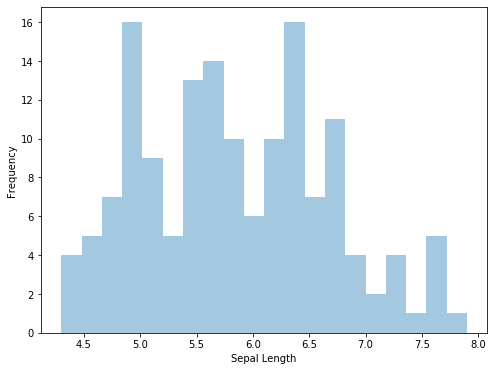

```python
plt.figure(figsize = (8,6))
sns.distplot(iris['sepal length (cm)'], bins = 20, hist = True, kde = False, color = '#1f77b4')
# Alternate - plt.hist(iris['sepal length (cm)'], bins = 20, density = True)
plt.xlabel('Sepal Length')
plt.ylabel('Frequency')
plt.show()
```

You may change “bins=” and “color=” to have different appearance.

### 2.1.0.2 Density plot – Fitted curve for histogram

Density plot is a nonparametric fitting

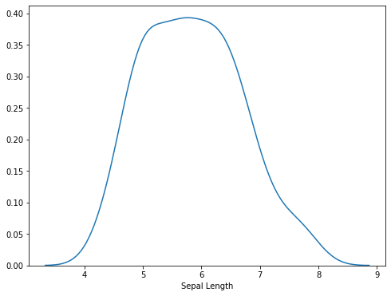

```python
plt.figure(figsize = (8,6))
sns.distplot(iris['sepal length (cm)'], bins = 20, hist = False, kde = True)
# Alternate - iris['sepal length (cm)'].plot(kind = 'density')
plt.xlabel('Sepal Length')
plt.show()
```

### 2.1.0.3 Combine the histogram and the density chart.

You can make the plot more elegant with different options. For example, adding a title, adjusting the axis range, renaming the axis label, and so on…

You can also add curve on top of an existing plot by writing another plot statement.

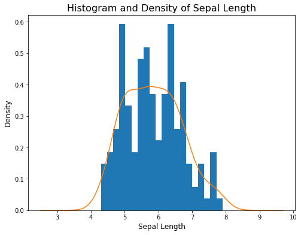

```python
plt.figure(figsize = (8,6))
plt.hist(iris['sepal length (cm)'], bins = 20, density = True)
iris['sepal length (cm)'].plot(kind = 'density')
plt.title('Histogram and Density of Sepal Length', fontsize=16)
plt.xlabel('Sepal Length', fontsize=12)
plt.ylabel('Density', fontsize=12)
plt.show()
```

## 2.2 Bar Chart

Bar chart is produces by using a vector of single data points, which is often a vector of summary statistics. Therefore, you need to preprocess your data, and get summary statistics before drawing the bar chart.

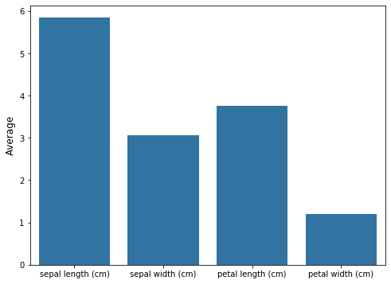

```python
plt.figure(figsize = (8,6))
aveg = iris.iloc[:,0:4].mean()
sns.barplot(aveg.index, aveg.values, color = '#1f77b4')
# Alternate - plt.bar(aveg.index, aveg.values)
plt.ylabel('Average', fontsize=12)
plt.show()
```

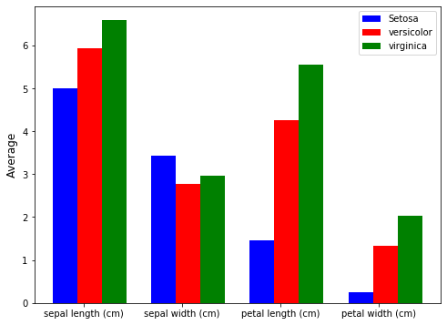

```python
aveg_group = iris.groupby('species').mean()
width = 0.25
plt.figure(figsize = (8,6))
ind = np.arange(4)
plt.bar(ind, aveg_group.iloc[0].values, width, color = 'b', label = 'Setosa')
plt.bar(ind + 0.25, aveg_group.iloc[1].values, width, color = 'r', label = 'versicolor')
plt.bar(ind + 0.5, aveg_group.iloc[2].values, width, color = 'g', label = 'virginica')
plt.xticks(ind + width*3 / 4, ('sepal length (cm)', 'sepal width (cm)', 'petal length (cm)', 'petal width (cm)'))
plt.ylabel('Average', fontsize=12)
plt.legend(loc='best')
plt.show()
```

## 2.3 Pie Chart

Pie chart is commonly used to visualize the proportion of different subject. It is similar to bar chart. You have to use a vector of single data points to produce a pie chart.

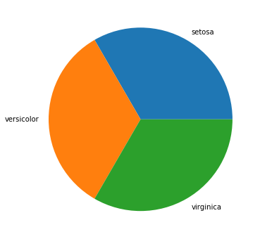

```python
count_values = pd.pivot_table(iris, index=['species'], aggfunc='count')
plt.figure(figsize = (8,6))
plt.pie(count_values.iloc[:,0], labels = count_values.index)
plt.show()
```

## 2.4 Box plot

Box plot can only be drawn for continuous variable.

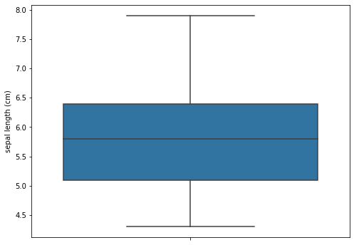

```python
plt.figure(figsize = (8,6))
sns.boxplot(iris['sepal length (cm)'], orient = 'v')
plt.show()
```

### 2.4.0.1 Draw box plot of multiple variables into one figure

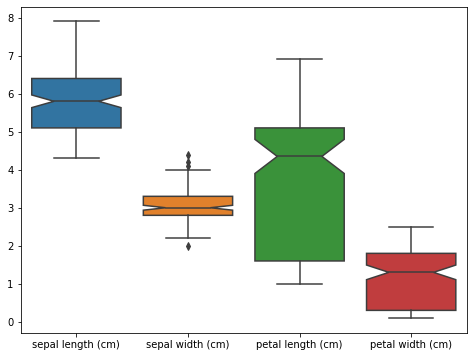

```python
plt.figure(figsize = (8,6))
sns.boxplot(data = iris, orient='v', notch = True)
plt.show()
```

### 2.4.0.2 Box plot by group

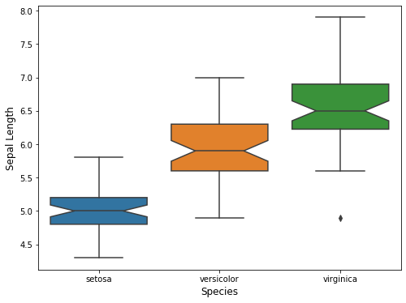

```python
plt.figure(figsize = (8,6))
sns.boxplot(x = 'species', y = 'sepal length (cm)', notch = True, data = iris)
plt.xlabel('Species', fontsize = 12)
plt.ylabel('Sepal Length', fontsize = 12)
plt.show()
```

## 2.5 Scatter Plot

### 2.5.1 Simple Scatter plot of two numerical variables

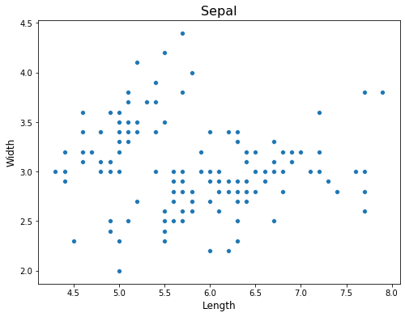

```python
plt.figure(figsize = (8,6))
sns.scatterplot(iris['sepal length (cm)'], iris['sepal width (cm)'])
# Alternate - plt.scatter(iris['sepal length (cm)'], iris['sepal width (cm)'])
plt.title('Sepal', fontsize = 16)
plt.xlabel('Length', fontsize = 12)
plt.ylabel('Width', fontsize = 12)
plt.show()
```

### 2.5.2 Scatter plot matrix (all paired variables)

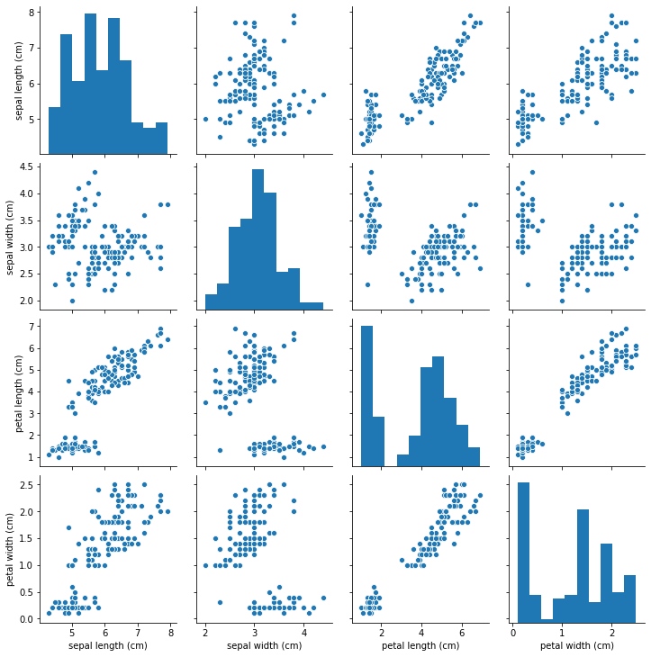

```python
plt.figure(figsize = (12,12))
sns.pairplot(iris)
# Alternate - pd.plotting.scatter_matrix(iris, figsize = (12,12),  marker='o', hist_kwds={'bins': 20}, s=60, alpha=.8)
plt.show()
```

## 2.6 Parallel Coordinates

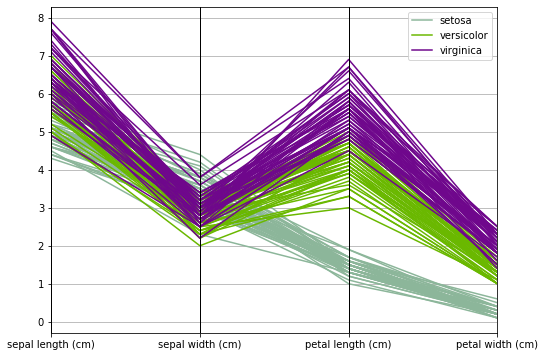

```python
plt.figure(figsize = (8,6))
pd.plotting.parallel_coordinates(iris, class_column = 'species')
plt.show()
```

## 2.7 Python Graphic Options

You may display multiple plots in one window (one figure).

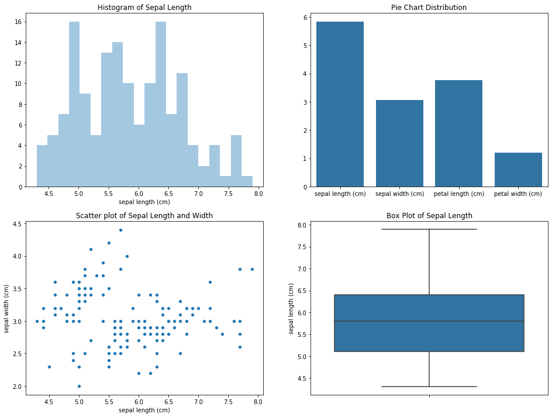

```python
fig, axes = plt.subplots(2,2, figsize=(16,12))
sns.distplot(iris['sepal length (cm)'], bins = 20, hist = True, kde = False, ax = axes[0][0])
axes[0][0].set_title('Histogram of Sepal Length', fontsize = 12)

sns.barplot(aveg.index, aveg.values, color = '#1f77b4', ax = axes[0][1])
axes[0][1].set_title('Pie Chart Distribution', fontsize = 12)

sns.scatterplot(iris['sepal length (cm)'], iris['sepal width (cm)'], ax = axes[1][0])
axes[1][0].set_title('Scatter plot of Sepal Length and Width', fontsize = 12)

sns.boxplot(iris['sepal length (cm)'], orient = 'v', ax = axes[1][1])
axes[1][1].set_title('Box Plot of Sepal Length', fontsize = 12)

plt.show()
```

## 3.1 Data Manipulation in Python

### 3.1.1 Filtering (Subsetting) data

Suppose we want to get the observations that have Sepal Length > 5 and Sepal Width > 4. We can use logical operators: != not equal to; == equal to; | or; & and.

```python
iris[(iris['sepal length (cm)'] > 5) & (iris['sepal width (cm)'] > 4)]
```

|  | sepal length (cm) | sepal width (cm) | petal length (cm) | petal width (cm) | species |
| --- | --- | --- | --- | --- | --- |
| 15 | 5.7 | 4.4 | 1.5 | 0.4 | setosa |
| 32 | 5.2 | 4.1 | 1.5 | 0.1 | setosa |
| 33 | 5.5 | 4.2 | 1.4 | 0.2 | setosa |

Suppose we want to get the observations that have Sepal Width between 3.5 and 4 and Species is Setosa.

```python
iris[((iris['sepal width (cm)'] >= 3.5) & (iris['sepal width (cm)'] < 4)) & (iris['species'] == 'setosa')]
```

|  | sepal length (cm) | sepal width (cm) | petal length (cm) | petal width (cm) | species |
| --- | --- | --- | --- | --- | --- |
| 0 | 5.1 | 3.5 | 1.4 | 0.2 | setosa |
| 4 | 5.0 | 3.6 | 1.4 | 0.2 | setosa |
| 5 | 5.4 | 3.9 | 1.7 | 0.4 | setosa |
| 10 | 5.4 | 3.7 | 1.5 | 0.2 | setosa |
| 16 | 5.4 | 3.9 | 1.3 | 0.4 | setosa |
| 17 | 5.1 | 3.5 | 1.4 | 0.3 | setosa |
| 18 | 5.7 | 3.8 | 1.7 | 0.3 | setosa |
| 19 | 5.1 | 3.8 | 1.5 | 0.3 | setosa |
| 21 | 5.1 | 3.7 | 1.5 | 0.4 | setosa |
| 22 | 4.6 | 3.6 | 1.0 | 0.2 | setosa |
| 27 | 5.2 | 3.5 | 1.5 | 0.2 | setosa |
| 36 | 5.5 | 3.5 | 1.3 | 0.2 | setosa |
| 37 | 4.9 | 3.6 | 1.4 | 0.1 | setosa |
| 40 | 5.0 | 3.5 | 1.3 | 0.3 | setosa |
| 43 | 5.0 | 3.5 | 1.6 | 0.6 | setosa |
| 44 | 5.1 | 3.8 | 1.9 | 0.4 | setosa |
| 46 | 5.1 | 3.8 | 1.6 | 0.2 | setosa |
| 48 | 5.3 | 3.7 | 1.5 | 0.2 | setosa |

### 3.1.2 Subsetting the Dataset: Random Sample

The following code random sample (without replacement) 90% of the original dataset and assgin them to a new variable iris_sample.

```python
iris_sample = iris.sample(frac=0.9, random_state=1)
iris_sample
```

|  | sepal length (cm) | sepal width (cm) | petal length (cm) | petal width (cm) | species |
| --- | --- | --- | --- | --- | --- |
| 14 | 5.8 | 4.0 | 1.2 | 0.2 | setosa |
| 98 | 5.1 | 2.5 | 3.0 | 1.1 | versicolor |
| 75 | 6.6 | 3.0 | 4.4 | 1.4 | versicolor |
| 16 | 5.4 | 3.9 | 1.3 | 0.4 | setosa |
| 131 | 7.9 | 3.8 | 6.4 | 2.0 | virginica |
| ... | ... | ... | ... | ... | ... |
| 22 | 4.6 | 3.6 | 1.0 | 0.2 | setosa |
| 61 | 5.9 | 3.0 | 4.2 | 1.5 | versicolor |
| 63 | 6.1 | 2.9 | 4.7 | 1.4 | versicolor |
| 7 | 5.0 | 3.4 | 1.5 | 0.2 | setosa |
| 86 | 6.7 | 3.1 | 4.7 | 1.5 | versicolor |

135 rows × 5 columns

### 3.1.3 Sorting

Sorting by one or more variables is a common operation that you can do with datasets. To do it with code, let’s suppose that you would like to find the top 5 rows in iris dataset with largest Sepal Length.

```python
iris.sort_values(by = ['sepal length (cm)'], ascending=False).head()
```

|  | sepal length (cm) | sepal width (cm) | petal length (cm) | petal width (cm) | species |
| --- | --- | --- | --- | --- | --- |
| 131 | 7.9 | 3.8 | 6.4 | 2.0 | virginica |
| 135 | 7.7 | 3.0 | 6.1 | 2.3 | virginica |
| 122 | 7.7 | 2.8 | 6.7 | 2.0 | virginica |
| 117 | 7.7 | 3.8 | 6.7 | 2.2 | virginica |
| 118 | 7.7 | 2.6 | 6.9 | 2.3 | virginica |

### 3.1.4 Select columns

If you want to select one or more variables of a data frame, there are two ways to do that. First is using indexing using .iloc function which use index position. Second is using .loc function which uses column name. For example, suppose we want to select variable “sepal length (cm)”:

```python
iris.iloc[:, 0]
```

```
0      5.1
1      4.9
2      4.7
3      4.6
4      5.0
      ...
145    6.7
146    6.3
147    6.5
148    6.2
149    5.9
Name: sepal length (cm), Length: 150, dtype: float64
```

```python
iris.loc[:, 'sepal length (cm)']
```

```
0      5.1
1      4.9
2      4.7
3      4.6
4      5.0
      ...
145    6.7
146    6.3
147    6.5
148    6.2
149    5.9
Name: sepal length (cm), Length: 150, dtype: float64
```

For multiple columns, you have to use double brackets "[[ ]]"

```python
iris.loc[:, ['sepal length (cm)', 'sepal width (cm)']]
```

|  | sepal length (cm) | sepal width (cm) |
| --- | --- | --- |
| 0 | 5.1 | 3.5 |
| 1 | 4.9 | 3.0 |
| 2 | 4.7 | 3.2 |
| 3 | 4.6 | 3.1 |
| 4 | 5.0 | 3.6 |
| ... | ... | ... |
| 145 | 6.7 | 3.0 |
| 146 | 6.3 | 2.5 |
| 147 | 6.5 | 3.0 |
| 148 | 6.2 | 3.4 |
| 149 | 5.9 | 3.0 |

150 rows × 2 columns

### 3.1.5 Renaming variable

```python
iris.rename(columns={'sepal length (cm)' : 'Sepal.Length', 'species' : 'Target'})
```

|  | Sepal.Length | sepal width (cm) | petal length (cm) | petal width (cm) | Target |
| --- | --- | --- | --- | --- | --- |
| 0 | 5.1 | 3.5 | 1.4 | 0.2 | setosa |
| 1 | 4.9 | 3.0 | 1.4 | 0.2 | setosa |
| 2 | 4.7 | 3.2 | 1.3 | 0.2 | setosa |
| 3 | 4.6 | 3.1 | 1.5 | 0.2 | setosa |
| 4 | 5.0 | 3.6 | 1.4 | 0.2 | setosa |
| ... | ... | ... | ... | ... | ... |
| 145 | 6.7 | 3.0 | 5.2 | 2.3 | virginica |
| 146 | 6.3 | 2.5 | 5.0 | 1.9 | virginica |
| 147 | 6.5 | 3.0 | 5.2 | 2.0 | virginica |
| 148 | 6.2 | 3.4 | 5.4 | 2.3 | virginica |
| 149 | 5.9 | 3.0 | 5.1 | 1.8 | virginica |

150 rows × 5 columns

### 3.1.6 Creating New Variables

```python
iris_2 = iris.copy()
iris_2['newvar'] = iris['sepal length (cm)']/ iris['sepal width (cm)']
iris_2.head()
```

|  | sepal length (cm) | sepal width (cm) | petal length (cm) | petal width (cm) | species | newvar |
| --- | --- | --- | --- | --- | --- | --- |
| 0 | 5.1 | 3.5 | 1.4 | 0.2 | setosa | 1.457143 |
| 1 | 4.9 | 3.0 | 1.4 | 0.2 | setosa | 1.633333 |
| 2 | 4.7 | 3.2 | 1.3 | 0.2 | setosa | 1.468750 |
| 3 | 4.6 | 3.1 | 1.5 | 0.2 | setosa | 1.483871 |
| 4 | 5.0 | 3.6 | 1.4 | 0.2 | setosa | 1.388889 |

## 3.1.7 Missing values

### 3.1.7.1 Detect missing values

Let's create a dummy dataset iris_2 replacing values 5.0 with missing values.

```python
iris_2.replace(5.0, np.NaN, inplace = True)
```

```python
# How many missing values are in sepal length column?
iris_2['sepal length (cm)'].isna().sum()
```

```
10
```

```python
# How many missing values are in each variable?
iris_2.isna().sum(axis = 0)
```

```
sepal length (cm)    10
sepal width (cm)      0
petal length (cm)     4
petal width (cm)      0
species               0
newvar                0
dtype: int64
```

### 3.1.7.2 How to deal with missing values?

- Simply delete those observations(rows) that contains missing value.
- Impute missing values by certain statistics, predictions or random number from estimated distributions.

```python
# Removing rows containing missing values
iris_3 = iris_2.dropna(axis = 0)
iris_3.shape
```

```
(136, 6)
```

```python
# Removing columns containing missing values
iris_3 = iris_2.dropna(axis = 1)
iris_3.shape
```

```
(150, 4)
```

# 4 Classification Analysis (Supervised Learning)

## 4.1 K-Nearest Neighbor (KNN)

In order to demonstrate this simple machine learning algorithm, I use Iris dataset, a famous dataset for almost all machine learning courses, and apply KNN onto the dataset to train a classifier for Iris Species.

```python
from sklearn.model_selection import train_test_split
from sklearn.neighbors import KNeighborsClassifier
```

### 4.1.1 Load and prepare the data

```python
data = datasets.load_iris()
iris = pd.DataFrame(data.data, columns = data.feature_names)
target = data.target
iris.head()
```

|  | sepal length (cm) | sepal width (cm) | petal length (cm) | petal width (cm) |
| --- | --- | --- | --- | --- |
| 0 | 5.1 | 3.5 | 1.4 | 0.2 |
| 1 | 4.9 | 3.0 | 1.4 | 0.2 |
| 2 | 4.7 | 3.2 | 1.3 | 0.2 |
| 3 | 4.6 | 3.1 | 1.5 | 0.2 |
| 4 | 5.0 | 3.6 | 1.4 | 0.2 |

```python
# Creating test and
X_train, X_test, y_train, y_test = train_test_split(iris, target, test_size = 0.3, random_state = 0)
```

### 4.1.2 Train the model

```python
model = KNeighborsClassifier(n_neighbors=3)
model.fit(X_train, y_train)
```

```
KNeighborsClassifier(n_neighbors=3)
```

```python
model.predict(X_train)
```

```
array([1, 2, 2, 1, 2, 1, 2, 1, 1, 2, 2, 1, 2, 1, 2, 1, 0, 2, 1, 1, 1, 1,
       2, 0, 0, 2, 1, 0, 0, 1, 0, 2, 1, 0, 1, 2, 1, 0, 2, 2, 2, 2, 0, 0,
       2, 2, 0, 2, 0, 2, 2, 0, 0, 2, 0, 0, 0, 1, 2, 2, 0, 0, 0, 1, 1, 0,
       0, 1, 0, 2, 1, 2, 1, 0, 2, 0, 2, 0, 0, 2, 0, 2, 1, 1, 1, 2, 2, 2,
       1, 0, 1, 2, 2, 0, 1, 1, 2, 1, 0, 0, 0, 2, 1, 2, 0])
```

```python
(model.predict(X_train) != y_train).sum()
```

```
4
```

### 4.1.3 Prediction accuracy

Here I use test set to create contingency table and show the performance of classifier.

```python
y_pred = model.predict(X_test)
data = pd.DataFrame({'Predicted': y_pred, 'Actual': y_test})
confusion_matrix = pd.crosstab(data['Actual'], data['Predicted'], rownames=['Actual'], colnames=['Predicted'])
print(confusion_matrix)
```

```
Predicted   0   1   2
Actual
0          16   0   0
1           0  17   1
2           0   0  11
```

```python
(y_pred != y_test).sum()
```

```
1
```

# 5 Clustering Analysis (Unsupervised Learning)

## 5.1 K-means clustering

K-means clustering with 5 clusters.

```python
from sklearn.cluster import KMeans
```

```python
model = KMeans(n_clusters=5, random_state = 0)
model.fit(iris)
```

```
KMeans(n_clusters=5, random_state=0)
```

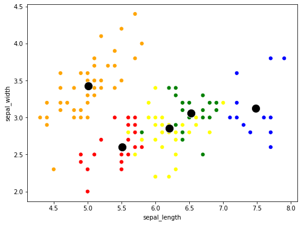

```python
kmeans = iris.copy()
kmeans_df = pd.DataFrame(kmeans)
kmeans_df.columns = ['sepal_length','sepal_width','petal_length','petal_width']
kmeans_df['species'] = model.predict(iris)

plt.figure(figsize = (8,6))
sns.scatterplot(x = 'sepal_length', y = 'sepal_width', hue = 'species', palette = ['orange','green','blue', 'red', 'yellow'], s = 50, data = kmeans_df)
sns.scatterplot(x = model.cluster_centers_[:,0], y = model.cluster_centers_[:,1], s = 200, color = 'black')
plt.legend().set_visible(False)
plt.show()
```

K-means clustering with 3 clusters.

```python
model = KMeans(n_clusters=3, random_state = 0)
model.fit(iris)
```

```
KMeans(n_clusters=3, random_state=0)
```

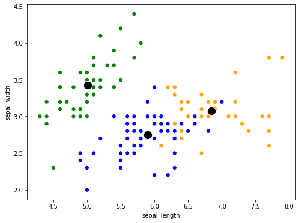

```python
kmeans = iris.copy()
kmeans_df = pd.DataFrame(kmeans)
kmeans_df.columns = ['sepal_length','sepal_width','petal_length','petal_width']
kmeans_df['species'] = model.predict(iris)

plt.figure(figsize = (8,6))
sns.scatterplot(x = 'sepal_length', y = 'sepal_width', hue = 'species', palette = ['orange','green','blue'], s = 50, data = kmeans_df)
sns.scatterplot(x = model.cluster_centers_[:,0], y = model.cluster_centers_[:,1], s = 200, color = 'black')
plt.legend().set_visible(False)
plt.show()
```

## 5.2 Hierarchical clustering

### 5.2.1 Dendrogram

```python
import scipy.cluster.hierarchy as sch
```

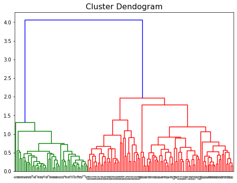

```python
plt.figure(figsize = (8,6))
dendrogram = sch.dendrogram(sch.linkage(iris, method='average'))
plt.title('Cluster Dendogram', fontsize = 16)
plt.show()
```

### 5.2.2 Model fitting

```python
from sklearn.cluster import AgglomerativeClustering
```

```python
model_3 = AgglomerativeClustering(n_clusters=3, affinity='euclidean', linkage='average')
model_3.fit(iris)
```

```
AgglomerativeClustering(linkage='average', n_clusters=3)
```

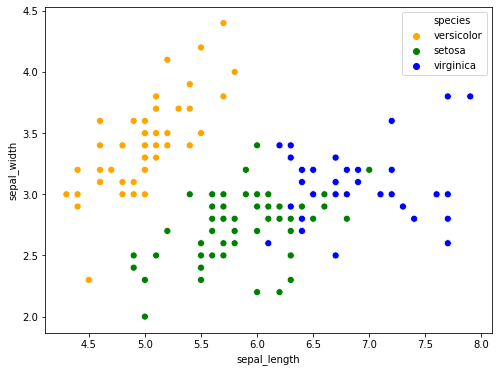

```python
clustering = iris.copy()
clustering_df = pd.DataFrame(clustering)
clustering_df.columns = ['sepal_length','sepal_width','petal_length','petal_width']
clustering_df['species'] = model_3.labels_
clustering_df.replace({'species': {0: 'setosa', 1: 'versicolor', 2 : 'virginica'}}, inplace = True)

plt.figure(figsize = (8,6))
sns.scatterplot(x = 'sepal_length', y = 'sepal_width', hue = 'species', palette = ['orange','green','blue'], s = 50, data = clustering_df)
plt.show()
```